# INFS3202/7202 Lecture 4: Database Design Walkthrough

# Database Normalization: From Unnormalized to 3rd Normal Form

When designing a database, we want to:

- **Eliminate redundancy**
- **Ensure data consistency**
- **Make updates easy**

This process is called **normalization**, and it consists of multiple steps called **normal forms (NF)**. The goal is to reach **Third Normal Form (3NF)**, which ensures a well-structured database.

In this tutorial, we’ll start with an **unnormalized** bookstore table and normalize it step by step.

Below is a revised Markdown tutorial that walks you through transforming an unnormalized books table into a fully normalized database in 3NF. In this version, modifications occur at each stage—from 1NF (where an ID field is added to Books) through 2NF (splitting out repeated topic names) and finally to 3NF (ensuring no transitive dependencies remain). Each section shows the complete set of tables at that stage.

## Unnormalized Form (UNF)

Our initial dataset is stored in a single table that includes books, their authors, publishers, and a comma-separated list of topics. This design suffers from several issues:

- **Multi-valued attributes**: The **Topics** field contains multiple values.
- **Redundant data**: The same author and publisher information appears in multiple rows.
- **Update anomalies**: Changing an author or publisher’s details requires updating many rows.
- **Lack of a unique identifier**: No primary key exists for uniquely identifying rows.

**UNF Table**

| Title | Author | Publisher | Topics |
| --- | --- | --- | --- |
| The AI Revolution | John Smith | TechBooks Ltd. | AI, Machine Learning |
| Deep Learning 101 | John Smith | TechBooks Ltd. | Deep Learning, AI |
| Python for Everyone | Alice Johnson | CodePress | Python, Programming |
| Web Dev Basics | Mark Lee | WebWorld Publishing | HTML, CSS, JavaScript |
| Mastering CSS | Mark Lee | WebWorld Publishing | CSS, Design |

## First Normal Form (1NF)

**Goal**: Ensure each field contains atomic values and every row has a unique identifier.

### Modifications for 1NF:

1. **Atomicity**: Remove the comma-separated list in the **Topics** column.
2. **Primary Keys**: Add a unique identifier (Book_ID) to the **Books** table.
3. **Separate Entities**: Create dedicated tables for Authors and Publishers.

### 1NF Tables

**Books Table**

| Book_ID | Title | Author_ID | Publisher_ID |
| --- | --- | --- | --- |
| 1 | The AI Revolution | 1 | 1 |
| 2 | Deep Learning 101 | 1 | 1 |
| 3 | Python for Everyone | 2 | 2 |
| 4 | Web Dev Basics | 3 | 3 |
| 5 | Mastering CSS | 3 | 3 |

**Authors Table**

| Author_ID | Author_Name |
| --- | --- |
| 1 | John Smith |
| 2 | Alice Johnson |
| 3 | Mark Lee |

**Publishers Table**

| Publisher_ID | Publisher_Name |
| --- | --- |
| 1 | TechBooks Ltd. |
| 2 | CodePress |
| 3 | WebWorld Publishing |

**Book_Topics Table**  
*Now each row represents one topic for a book.*

| Book_ID | Topic |
| --- | --- |
| 1 | AI |
| 1 | Machine Learning |
| 2 | Deep Learning |
| 2 | AI |
| 3 | Python |
| 3 | Programming |
| 4 | HTML |
| 4 | CSS |
| 4 | JavaScript |
| 5 | CSS |
| 5 | Design |

At this stage, every column holds atomic values and each row is uniquely identified.

## Second Normal Form (2NF)

**Goal**: In addition to 1NF, remove partial dependencies so that every non-key attribute is fully dependent on the entire primary key.

### Issue in 1NF:

- In the **Book_Topics** table, topic names are repeated. If a topic name needs to change (for instance, a rebranding from “Machine Learning” to “ML”), multiple rows must be updated.

### Modifications for 2NF:

1. Create a separate **Topics** table that stores each unique topic with its own Topic_ID.
2. Update the **Book_Topics** table to reference topics by Topic_ID rather than by name.

### 2NF Tables

**Topics Table**

| Topic_ID | Topic_Name |
| --- | --- |
| 1 | AI |
| 2 | Machine Learning |
| 3 | Deep Learning |
| 4 | Python |
| 5 | Programming |
| 6 | HTML |
| 7 | CSS |
| 8 | JavaScript |
| 9 | Design |

**Book_Topics Table**  
*Now referencing topics by Topic_ID.*

| Book_ID | Topic_ID |
| --- | --- |
| 1 | 1 |
| 1 | 2 |
| 2 | 3 |
| 2 | 1 |
| 3 | 4 |
| 3 | 5 |
| 4 | 6 |
| 4 | 7 |
| 4 | 8 |
| 5 | 7 |
| 5 | 9 |

The **Books**, **Authors**, and **Publishers** tables remain unchanged from 1NF.

## Third Normal Form (3NF)

**Goal**: Remove transitive dependencies so that non-key attributes do not depend on other non-key attributes.

### Review and Considerations:

- In the original UNF table, details like author names and publisher names were stored with the book data, creating transitive dependencies.
- By moving author and publisher information into their own tables in 1NF, and further isolating topics in 2NF, these dependencies have been resolved.

### Modifications for 3NF:

No additional table splits are necessary because: - **Books** now only contains foreign keys (Author_ID and Publisher_ID) to the respective tables. - **Authors**, **Publishers**, and **Topics** contain only attributes that depend solely on their primary keys. - The **Book_Topics** table simply links books to topics via their IDs.

Thus, our database is now in Third Normal Form (3NF).

### Final 3NF Table Structure

**Books Table**

| Book_ID | Title | Author_ID | Publisher_ID |
| --- | --- | --- | --- |
| 1 | The AI Revolution | 1 | 1 |
| 2 | Deep Learning 101 | 1 | 1 |
| 3 | Python for Everyone | 2 | 2 |
| 4 | Web Dev Basics | 3 | 3 |
| 5 | Mastering CSS | 3 | 3 |

**Authors Table**

| Author_ID | Author_Name |
| --- | --- |
| 1 | John Smith |
| 2 | Alice Johnson |
| 3 | Mark Lee |

**Publishers Table**

| Publisher_ID | Publisher_Name |
| --- | --- |
| 1 | TechBooks Ltd. |
| 2 | CodePress |
| 3 | WebWorld Publishing |

**Topics Table**

| Topic_ID | Topic_Name |
| --- | --- |
| 1 | AI |
| 2 | Machine Learning |
| 3 | Deep Learning |
| 4 | Python |
| 5 | Programming |
| 6 | HTML |
| 7 | CSS |
| 8 | JavaScript |
| 9 | Design |

**Book_Topics Table**

| Book_ID | Topic_ID |
| --- | --- |
| 1 | 1 |
| 1 | 2 |
| 2 | 3 |
| 2 | 1 |
| 3 | 4 |
| 3 | 5 |
| 4 | 6 |
| 4 | 7 |
| 4 | 8 |
| 5 | 7 |
| 5 | 9 |

## Final Database Schema in DBML

Database Markup Language (DBML) is a simple, human-readable syntax used to define database structures. It is commonly used with dbdiagram.io to visualize database schemas.

With DBML, you can:

- Define tables and their columns
- Specify primary keys and foreign keys
- Show relationships between tables
- Keep your database schema clean and readable

A DBML Reference is available here: https://dbml.dbdiagram.io/docs/

```
Table Books {
  Book_ID int [primary key]
  Title varchar
  Author_ID int
  Publisher_ID int
}

Table Authors {
  Author_ID int [primary key]
  Author_Name varchar
}

Table Publishers {
  Publisher_ID int [primary key]
  Publisher_Name varchar
}

Table Topics {
  Topic_ID int [primary key]
  Topic_Name varchar
}

Table Book_Topics {
  Book_ID int
  Topic_ID int
  primary key (Book_ID, Topic_ID)
}

Ref: Books.Author_ID > Authors.Author_ID
Ref: Books.Publisher_ID > Publishers.Publisher_ID
Ref: Book_Topics.Book_ID > Books.Book_ID
Ref: Book_Topics.Topic_ID > Topics.Topic_ID
```

## 🔗 Render the Schema

👉 Copy and paste the DBML code into [dbdiagram.io](https://dbdiagram.io/) to visualize your database schema.

Here is the schema for the Bookstore:

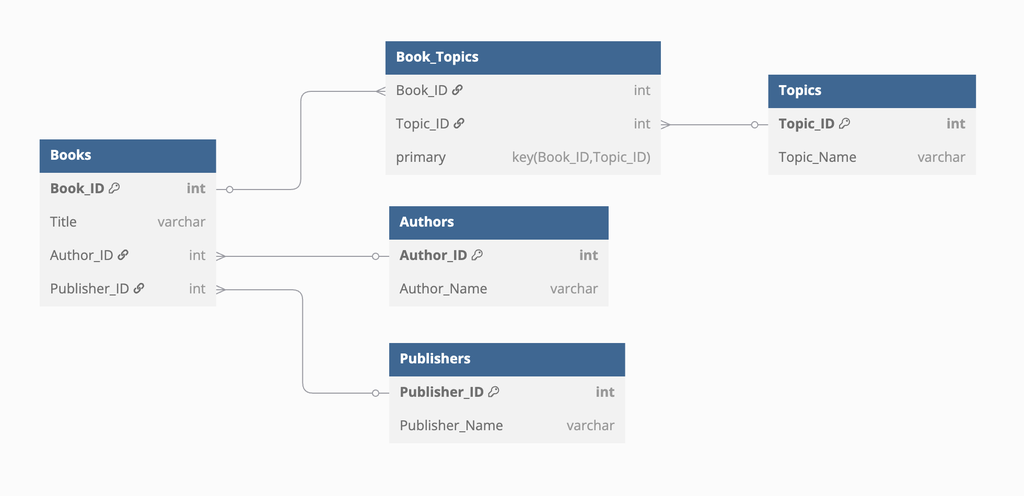

## 🎯 Final Takeaways

By normalizing, we **eliminated redundancy**, **improved consistency**, and **made our database scalable**. 🚀